# Going Beyond Brand Preference to Build Strategic Partnerships

Anita Rijal

2/13/2020

[figure not shown]

## Table of contents

- More Customers Prefer Elago
- Results of the c5.0 Model
- Comparing Accuracy of the Two Predictive Models

  i. Random Forest Classifier  
  ii. C5.0 Classifier
- What do the predictions mean for Blackwell?

### More Customers Prefer Elago

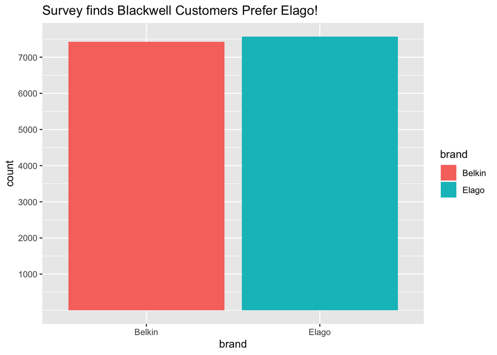

```r
visual<-ggplot(total, aes(x=brand, fill=brand))+
  labs(title = "Survey finds Blackwell Customers Prefer Elago!")
visual+geom_bar()+
  scale_y_continuous(breaks = seq(1000,9000,1000))
```

### Our Model Predicts…

According to our prediction model findings, of the 5000 customers with missing bradn preference data: * 2777 were predicted to prefer Belkin * 2223 were predicted to prefer Elago

#### The results are summarised in the table below:

```r
clean <- within(incomplete, rm(brand))
mypredictions <- cbind(clean, "brand" = c5results)
summary(mypredictions)
```

```
##      salary             age                elevel           car
##  Min.   :-1.7320   Min.   :-1.694189   Min.   :1.000   Min.   : 1.0
##  1st Qu.:-0.6970   1st Qu.:-0.841738   1st Qu.:2.000   1st Qu.: 5.0
##  Median : 0.1938   Median : 0.010712   Median :2.000   Median :10.0
##  Mean   : 0.1859   Mean   : 0.003291   Mean   :2.411   Mean   :10.2
##  3rd Qu.: 1.0546   3rd Qu.: 0.863163   3rd Qu.:3.000   3rd Qu.:15.0
##  Max.   : 2.0380   Max.   : 1.715614   Max.   :4.000   Max.   :20.0
##     zipcode          credit         brand
##  Min.   :0.000   Min.   :438.1   Belkin:2777
##  1st Qu.:2.000   1st Qu.:582.8   Elago :2223
##  Median :4.000   Median :644.1
##  Mean   :4.043   Mean   :645.5
##  3rd Qu.:6.000   3rd Qu.:709.1
##  Max.   :8.000   Max.   :849.0
```

**By combining the above brand predictions with the completed brand responses, in total our customer survey responses are summarised below:**

```r
clean <- within(incomplete, rm(brand))
mypredictions <- cbind(clean, "brand" = c5results)

total <- rbind(complete, mypredictions)
summary(total)
```

```
##      salary               age          elevel        car          zipcode
##  Min.   :    -1.73   Min.   :-1.6942   1:1991   3      :1293   6      :1709
##  1st Qu.:     1.05   1st Qu.: 0.8632   2:6584   8      :1121   8      :1707
##  Median : 52107.93   Median :35.0000   3:5416   7      :1082   4      :1688
##  Mean   : 56598.23   Mean   :33.2088   4:1009   20     :1076   5      :1681
##  3rd Qu.:101065.86   3rd Qu.:57.0000            1      : 966   2      :1670
##  Max.   :150000.00   Max.   :80.0000            15     : 863   7      :1662
##                                                 (Other):8599   (Other):4883
##      credit         brand
##  Min.   :423.7   Belkin:7429
##  1st Qu.:576.8   Elago :7571
##  Median :638.3
##  Mean   :638.9
##  3rd Qu.:702.7
##  Max.   :849.0
##
```

### Should We Trust the Model’s Predictions?

Based on our initial exploratory data analysis looking at the completed survey responses, we chose two predictors for our models:

*1) Age* *2) Salary*

Furthermore, we saw no strong trends in brand preference with the other factors (credit, region, education level etc). To improve the performance of the classifier, our model did not include other customer attributes to predict brand preference.

*Below is a comparison of the accuracy for both the c5.0 Model and the Random Forest Models:*

```r
remodel<- resamples(list(rf=RFmodel, c5=C5Model))
summary(remodel)
```

```
##
## Call:
## summary.resamples(object = remodel)
##
## Models: rf, c5
## Number of resamples: 10
##
## Accuracy
##         Min.   1st Qu.    Median      Mean   3rd Qu.      Max. NA's
## rf 0.7428571 0.7500892 0.7571429 0.7577523 0.7626042 0.7814286    0
## c5 0.7689016 0.7860714 0.7942857 0.7948901 0.8072802 0.8128571    0
##
## Kappa
##         Min.   1st Qu.    Median      Mean   3rd Qu.      Max. NA's
## rf 0.4836912 0.4998231 0.5134758 0.5140849 0.5241291 0.5608856    0
## c5 0.5451953 0.5769479 0.5915290 0.5933944 0.6173869 0.6273933    0
```

**Summary of the Confusion Matrix for the Random Forest Model**

```r
accuracy_RF<- caret::confusionMatrix(data =rftest , reference = proctest$brand)
accuracy_RF
```

```
## Confusion Matrix and Statistics
##
##           Reference
## Prediction Belkin Elago
##     Belkin   1009   375
##     Elago     386  1229
##
##                Accuracy : 0.7462
##                  95% CI : (0.7303, 0.7617)
##     No Information Rate : 0.5348
##     P-Value [Acc > NIR] : <2e-16
##
##                   Kappa : 0.4898
##
##  Mcnemar's Test P-Value : 0.717
##
##             Sensitivity : 0.7233
##             Specificity : 0.7662
##          Pos Pred Value : 0.7290
##          Neg Pred Value : 0.7610
##              Prevalence : 0.4652
##          Detection Rate : 0.3364
##    Detection Prevalence : 0.4615
##       Balanced Accuracy : 0.7448
##
##        'Positive' Class : Belkin
##
```

```r
#alternative accuracy function
postResample(pred = rftest, obs = proctest$brand)
```

```
##  Accuracy     Kappa
## 0.7462487 0.4897586
```

**Summary of the Confusion Matrix for the C5.0 Model**

```r
#accuracy of c5model
c5_accuracy <- confusionMatrix(C5Model, newdata= proctest)
c5_accuracy
```

```
## Cross-Validated (10 fold) Confusion Matrix
##
## (entries are percentual average cell counts across resamples)
##
##           Reference
## Prediction Belkin Elago
##     Belkin   41.1  15.1
##     Elago     5.4  38.4
##
##  Accuracy (average) : 0.7949
```

```r
#alternative function for accuracy
postResample(pred = c5test, obs = proctest$brand)
```

```
##  Accuracy     Kappa
## 0.8036012 0.6103623
```

### What do the predictions mean for Blackwell?

     **Is Blackwell targetting a specific customer segment to boost sales?**
     - If Blackwell’s core customer base is a younger demographic, the team might be better off pursuing a relationship with Elago. Our exploratory data analysis shows
     - Customers who were 55 years and younger prefer Elago products. * Median age of customers who prefered Elago was ~ 40 years. * Median age for customers who prefered Belkin was ~ 60 years.

       **What are Blackwell’s top selling products?**
       - Rather than choosing either Elago or Belkin, Blackwell might decide to pursue a strategic partnership based on product. Working with Elago on prodcuts that sell better with younger demographic, and working with Belkin on products that sell better with an older demographic.

       **High end vs low end products?**
       - We know from our exploratory data analaysis that:
       - Customers who earned between 65,000 to 110,000 were more likely to prefer Belkin (median salary was 85,000).
       - Customers who earned between 45,000 to 125,000 were more likely to prefer Elago (the median salary was 80,000).
       - Blackwell might want to consider ordering more affordable products from Elago while pursuing a partnership with Belkin on more premium products.